# p8105_hw6_qz2527

kindle zhang

2023-11-29

# Problem 1

```r
homicide_df =
  read_csv("./data_file/homicide-data.csv",
           na = c("", "NA", "Unknown")) |>
  janitor::clean_names() |>
  mutate(
    city_state = str_c(city , ", ", state),
    # or we can use
    # city_state = str_c(city ,state, sep = ", ")
    victim_age = as.numeric(victim_age),
    resolution = as.numeric(disposition == "Closed by arrest"),
    # or we can use
    #   resolution = case_when(
    #     disposition == "Closed without arrest" ~ 0,
    #     disposition == "Open/No arrest"        ~ 0,
    #     disposition == "Closed by arrest"      ~ 1)
    # )
  ) |>
  filter(victim_race %in% c("White", "Black")) |>
  filter(!(city_state %in% c("Dallas, TX", "Phoenix, AZ", "Kansas City, MO", "Tulsa, AL"))) |>
  select(city_state, resolution, victim_age, victim_sex, victim_race)
```

we make a general regression over different predictors and save the outcome. Then I tidy the outcome and find the confidential interval.

```r
baltomore_glm =
  homicide_df |>
  filter(city_state == "Baltimore, MD") |>
  glm(resolution ~ victim_age + victim_sex + victim_race, family = binomial(), data = _)

baltomore_glm |>
  broom::tidy() |>
  mutate(
    OR = exp(estimate),
    OR_CI_upper = exp(estimate + 1.96 * std.error),
    OR_CI_lower = exp(estimate - 1.96 * std.error)
  ) |>
  filter(term == "victim_sexMale") |>
  select(OR, OR_CI_lower, OR_CI_upper) |>
  knitr::kable(digits = 3)
```

| OR | OR_CI_lower | OR_CI_upper |
| --- | --- | --- |
| 0.426 | 0.325 | 0.558 |

```r
model_results =
  homicide_df |>
  nest(data = -city_state) |>
  mutate(
    models = map(data, \(df) glm(resolution ~ victim_age + victim_sex + victim_race, family = binomial(), data = df)),
    tidy_models = map(models, broom::tidy)
  ) |>
  select(-data, -models) |>
  unnest(cols = tidy_models) |>
  mutate(
    OR = exp(estimate),
    OR_CI_upper = exp(estimate + 1.96 * std.error),
    OR_CI_lower = exp(estimate - 1.96 * std.error)
  ) |>
  filter(term == "victim_sexMale") |>
  select(city_state, OR, OR_CI_lower, OR_CI_upper)

model_results |>
  slice(1:5) |>
  knitr::kable(digits = 3)
```

| city_state | OR | OR_CI_lower | OR_CI_upper |
| --- | --- | --- | --- |
| Albuquerque, NM | 1.767 | 0.831 | 3.761 |
| Atlanta, GA | 1.000 | 0.684 | 1.463 |
| Baltimore, MD | 0.426 | 0.325 | 0.558 |
| Baton Rouge, LA | 0.381 | 0.209 | 0.695 |
| Birmingham, AL | 0.870 | 0.574 | 1.318 |

Below we generate a plot of the estimated ORs and CIs for each city, ordered by magnitude of the OR from smallest to largest. From this plot we see that most cities have odds ratios that are smaller than 1, suggesting that crimes with male victims have smaller odds of resolution compared to crimes with female victims after adjusting for victim age and race. This disparity is strongest in New yrok. In roughly half of these cities, confidence intervals are narrow and do not contain 1, suggesting a significant difference in resolution rates by sex after adjustment for victim age and race.

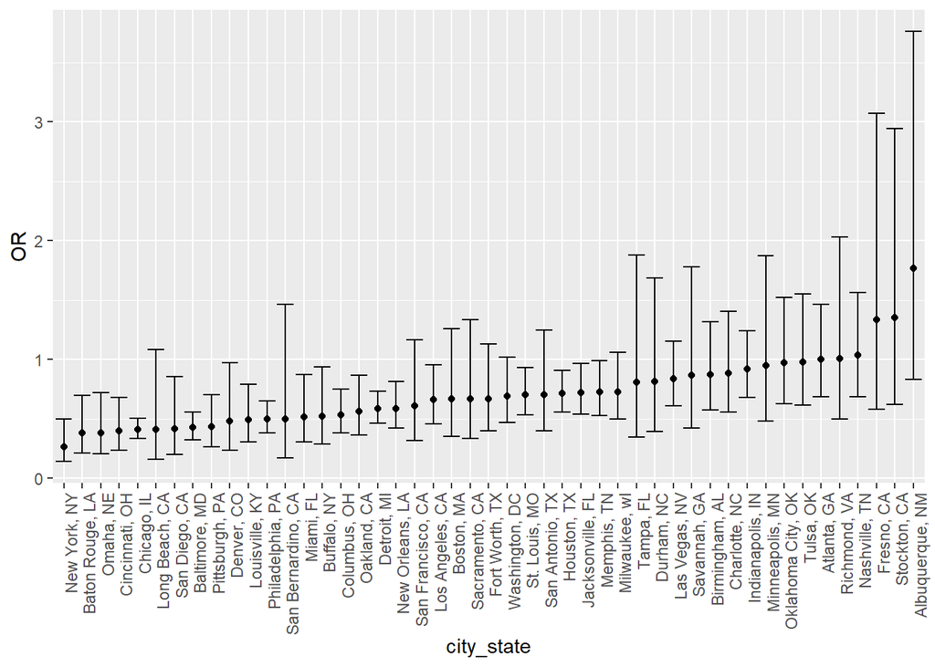

```r
model_results |>
  mutate(city_state = fct_reorder(city_state, OR)) |>
  ## like reorder
  ggplot(aes(x = city_state, y = OR)) + geom_point() +
  geom_errorbar(aes(ymin = OR_CI_lower, ymax = OR_CI_upper)) +
  theme(axis.text.x = element_text(angle = 90, hjust = 1))
```

# Problem 2

first, I import the data and tidy it.

```r
weather_df =
  rnoaa::meteo_pull_monitors(
    c("USW00094728"),
    var = c("PRCP", "TMIN", "TMAX"),
    date_min = "2022-01-01",
    date_max = "2022-12-31") |>
  mutate(
    name = recode(id, USW00094728 = "CentralPark_NY"),
    tmin = tmin / 10,
    tmax = tmax / 10) |>
  select(name, id, everything())
```

```
## using cached file: C:\Users\zhang\AppData\Local/R/cache/R/rnoaa/noaa_ghcnd/USW00094728.dly
```

```
## date created (size, mb): 2023-09-28 10:20:11.695766 (8.541)
```

```
## file min/max dates: 1869-01-01 / 2023-09-30
```

make a function to bootstrap first.

```r
boot_sample = function(df){
  sample_frac(df, replace  = TRUE)
}
```

make a multiple linear regression

```r
weather_fit =
  weather_df |>
    lm(tmax ~ tmin + prcp, data = _)

weather_fit |>
    broom::tidy()
```

```
## # A tibble: 3 × 5
##   term        estimate std.error statistic   p.value
##   <chr>          <dbl>     <dbl>     <dbl>     <dbl>
## 1 (Intercept)  8.04      0.230      35.0   4.39e-118
## 2 tmin         1.01      0.0162     62.7   1.43e-196
## 3 prcp        -0.00154   0.00210    -0.733 4.64e-  1
```

Get the residuals and plot it

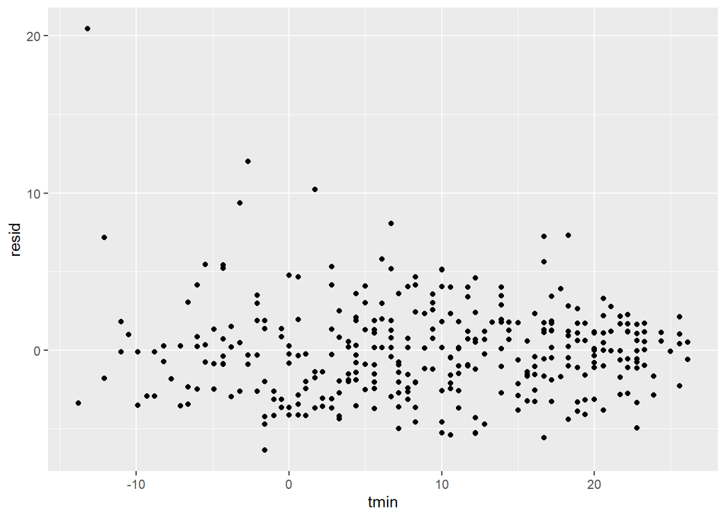

```r
weather_df |>
  modelr::add_residuals(weather_fit) |>
  ggplot(aes(x = tmin, y = resid)) +
  geom_point()
```

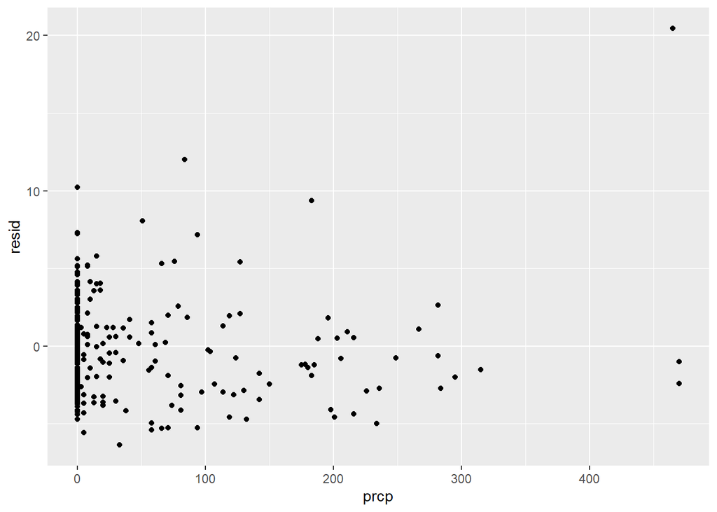

```r
weather_df |>
  modelr::add_residuals(weather_fit) |>
  ggplot(aes(x = prcp, y = resid)) +
  geom_point()
```

Then, I use the bootstrapping and find the $\hat{r}^2$ and $log(\hat{\beta}_1*\hat{\beta}_2)$

```r
boot_straps =
  tibble(strap_number = 1:5000) |>
  mutate(
    strap_sample = map(strap_number, \(df) boot_sample(df = weather_df)),
    models = map(strap_sample,\(df) lm(tmax ~ tmin + prcp, data = df)),
    results_1 = map(models, broom::tidy),
    results_2 = map(models, broom::glance)) |>
  select(strap_number, starts_with("results")) |>
  unnest(results_1, results_2) |>
  janitor::clean_names() |>
  filter(term %in% c("tmin", "prcp")) |>
  select(strap_number, term, estimate, adj_r_squared) |>
  pivot_wider(
    names_from = term,
    values_from = estimate
  ) |>
  rename(tmin_esti = tmin, prcp_esti = prcp) |>
  mutate(ln_beta1_beta2 = log(tmin_esti * prcp_esti)) |>
  select(strap_number, adj_r_squared, ln_beta1_beta2)
boot_straps
```

```
## # A tibble: 5,000 × 3
##    strap_number adj_r_squared ln_beta1_beta2
##           <int>         <dbl>          <dbl>
##  1            1         0.898          -5.44
##  2            2         0.928         NaN
##  3            3         0.925         NaN
##  4            4         0.931         NaN
##  5            5         0.914         NaN
##  6            6         0.917          -7.18
##  7            7         0.922         NaN
##  8            8         0.909          -6.65
##  9            9         0.910          -6.21
## 10           10         0.939         NaN
## # ℹ 4,990 more rows
```

we will plot the estimate’s distribution

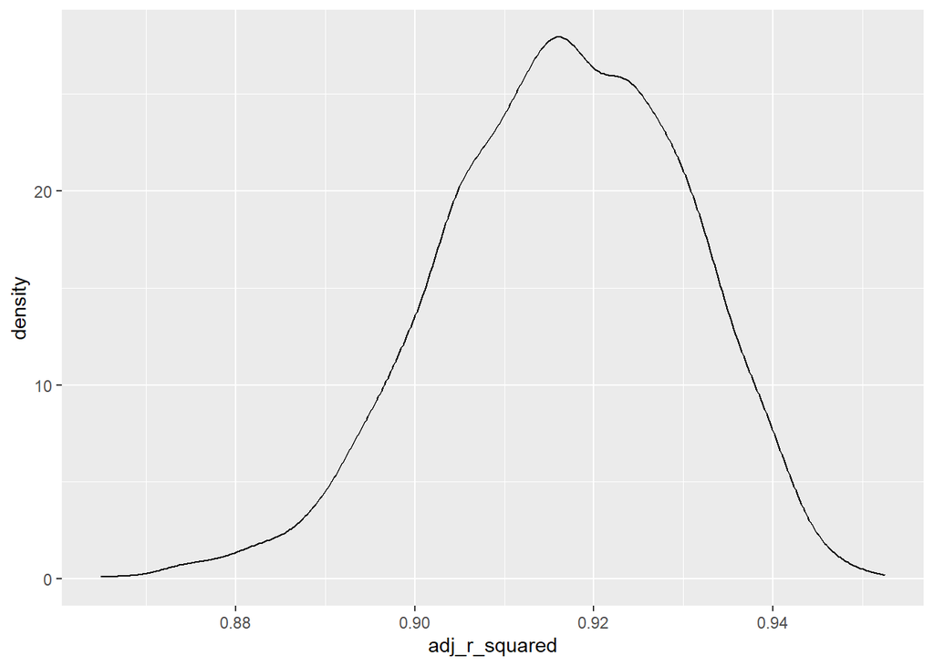

```r
boot_straps |>
  ggplot(aes(x = adj_r_squared)) +
  geom_density()
```

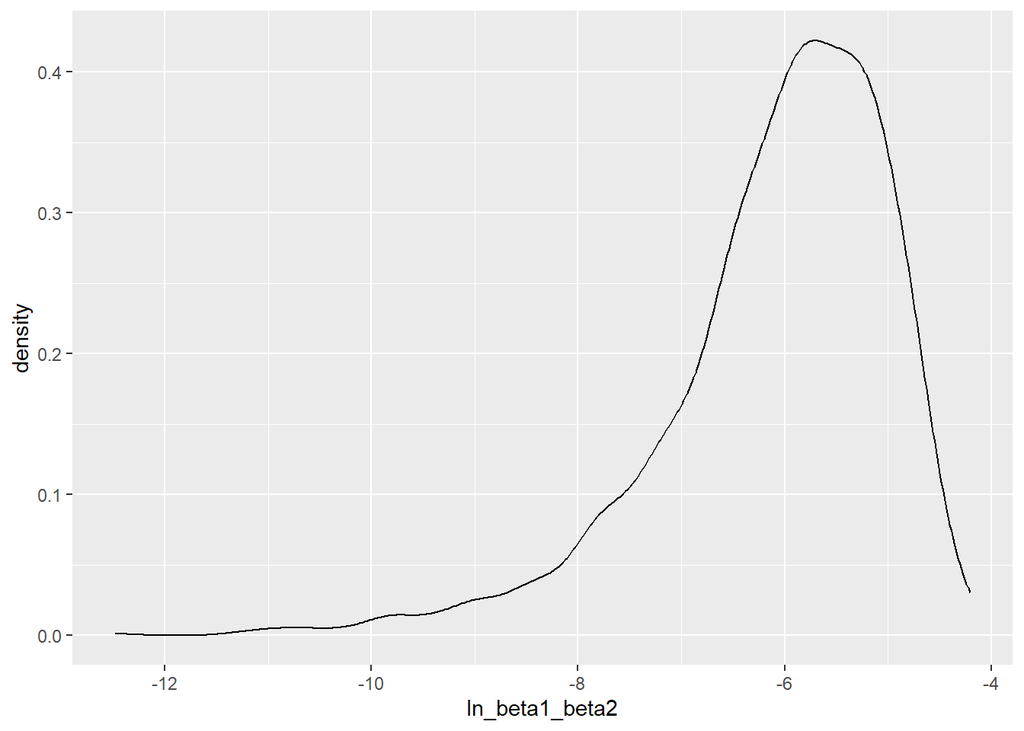

```r
boot_straps |>
  ggplot(aes(x = ln_beta1_beta2)) +
  geom_density()
```

we can find that the R squared value is between the 0.88 and 0.94, which means the general smulation effect is perfect.

Then, identify the 2.5% and 97.5% quantiles to provide a 95% confidence interval for these two variable.

```r
boot_straps |>
  pivot_longer(
    adj_r_squared : ln_beta1_beta2,
    names_to = "term",
    values_to = "estimate"
  ) |>
  group_by(term) |>
  summarise(
    ci_lower = quantile(estimate, 0.025, na.rm = TRUE),
    ci_higher = quantile(estimate, 0.975, na.rm = TRUE)
  ) |>
  knitr::kable()
```

| term | ci_lower | ci_higher |
| --- | --- | --- |
| adj_r_squared | 0.8879337 | 0.9403535 |
| ln_beta1_beta2 | -8.9815594 | -4.6016727 |

Then we can find the quantile of these two variables under a 95% confidence level interval

# Problem 3

import the data and tidy the data, I drop the variable pnumlbw and pnumsga cause all the data is 0, it’s meaningless to be a predictor

```r
birth_data =
  read_csv("./data_file/birthweight.csv",
           na = c("", "NA", "Unknown")) |>
  janitor::clean_names() |>
  mutate(
    babysex = fct(case_when(
      ## fct_relevel/reorder/infreq/inseq
      babysex == 1 ~ "male",
      babysex == 2 ~ "female")),
    frace = fct(
      case_when(
        frace == 1 ~ "White",
        frace == 2 ~ "Black",
        frace == 3 ~ "Asian",
        frace == 4 ~ "Puerto Rican",
        frace == 8 ~ "Other",
        frace == 9 ~ "Unknown"
      )
    ),
    mrace = fct(
      case_match(
        mrace,
        1 ~ "White",
        2 ~ "Black",
        3 ~ "Asian",
        4 ~ "Puerto Rican",
        8 ~ "Other"
      )
    ),
    malform = fct(case_match(malform,
                             0 ~ "absent",
                             1 ~ "present")),
  ) |>
  select(-pnumlbw, -pnumsga) |>
  drop_na()
legth_id =
  birth_data |>
  nrow()

id = c(1: legth_id)

birth_data =
  birth_data |>
  mutate(id = id) |>
  relocate(id, bwt)
```

First, I will make a multiple regression with all covariates being predictors

```r
reg_birth =
  birth_data |>
  select(-id) |>
  lm(bwt ~ ., data = _)

broom::tidy(reg_birth)
```

```
## # A tibble: 23 × 5
##    term               estimate std.error statistic   p.value
##    <chr>                 <dbl>     <dbl>     <dbl>     <dbl>
##  1 (Intercept)       -6237.      660.      -9.45   5.56e- 21
##  2 babysexmale         -28.7       8.47    -3.39   7.02e-  4
##  3 bhead               131.        3.45    37.9    2.16e-271
##  4 blength              75.0       2.02    37.1    1.75e-261
##  5 delwt                 4.10      0.395   10.4    5.62e- 25
##  6 fincome               0.290     0.180    1.61   1.07e-  1
##  7 fraceBlack           14.3      46.2      0.311  7.56e-  1
##  8 fraceAsian           21.2      69.3      0.306  7.59e-  1
##  9 fracePuerto Rican   -47.0      44.7     -1.05   2.93e-  1
## 10 fraceOther            4.30     74.1      0.0580 9.54e-  1
## # ℹ 13 more rows
```

According to the table, I simply choose several variables with a particularly small p-value to be my model’s predictor, which are `babysex`, `bhead`, `blength`, `delwt`. Of course my model isn’t the optimal, but it doesn’t matter.

Then I get the predictions of birth weight and the residuals, and plota a picture using these two variables

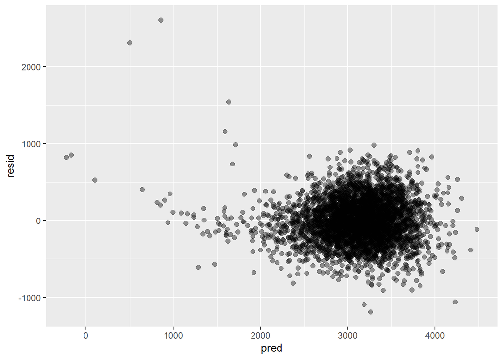

```r
model_fit_1 =
  birth_data |>
  select(bwt, babysex, bhead, blength, delwt) |>
  lm(bwt ~ ., data = _)

birth_data_mymodel =
  birth_data |>
  select(bwt, babysex, bhead, blength, delwt) |>
  modelr::add_predictions(model_fit_1) |>
  modelr::add_residuals(model_fit_1)

birth_data_mymodel |>
  ggplot(aes(x = pred, y =resid)) +
  geom_point(alpha = .4, size = 2)
```

according to the picture, we can find except some outliers, the general simulation effect is good.

Next, we will use a cross validation to compare my model and other two models’ cross-validated prediction error. Therefore, we set 100 train and test groups.

```r
cv_df =
  crossv_mc(birth_data, n = 100)

cv_df =
  cv_df |>
  mutate(train = purrr::map(train, as_tibble),
         test = purrr::map(test, as_tibble))
```

use three different models to make regressions with all groups.

```r
cv_df =
  cv_df |>
  mutate(
    my_model  = map(train, \(df) lm(bwt ~ babysex + bhead + blength + delwt, data = df)),
    model_1  = map(train, \(df) lm(bwt ~ blength + gaweeks, data = df)),
    model_2  = map(train, \(df) lm(bwt ~ bhead + babysex + blength + bhead * babysex + bhead * blength + babysex * blength + bhead * babysex * blength, data = df))) |>
  mutate(
    rmse_mymodel = map2_dbl(my_model, test, \(mod, df) rmse(model = mod, data = df)),
    rmse_model_1 = map2_dbl(model_1, test, \(mod, df) rmse(model = mod, data = df)),
    rmse_model_2 = map2_dbl(model_2, test, \(mod, df) rmse(model = mod, data = df)))
```

focus in the residual and plot them

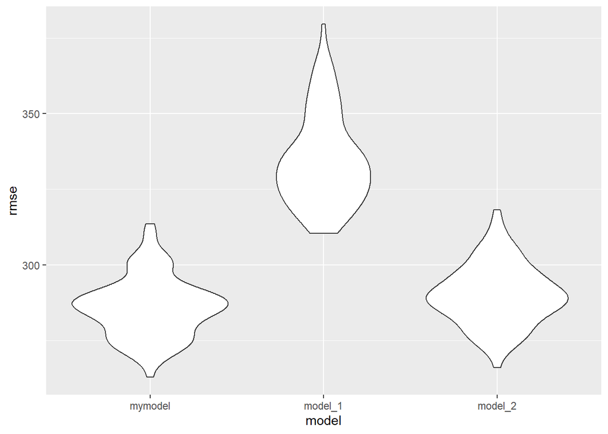

```r
cv_df |>
  select(starts_with("rmse")) |>
  pivot_longer(
    everything(),
    names_to = "model",
    values_to = "rmse",
    names_prefix = "rmse_") |>
  mutate(model = fct_inorder(model)) |>
  ggplot(aes(x = model, y = rmse)) + geom_violin()
```

according to the outcome, I find that my model’s fitting effect is the best and easy to interpret than other two methods.